## Group 13: Sanjit Saji, Shreya Rathi & Aryan Shah

# **Executive Summary: Predicting IPL Match Outcomes**

Our analysis for this project explores how we can estimate the chance of winning as the match progresses in the Indian Premier League (IPL). We use detailed ball-by-ball data from every men’s IPL match that is available through the Cricsheet database. Our group aims to quantify how factors like remaining runs, wickets in hand, and scoring rate influence the likelihood of a successful chase. The goal is to build an interpretable and data-driven model that can estimate, at any point in the second innings, what is the probability that the current batting team will win.

## **Approach and Data**

The data consists of every ball delivery from IPL matches from 2008 to 2025. We trained the model on data from 2008-2024, focusing on second-innings situations (where teams chase a set target). The data contained over a million deliveries, which were then cleaned to remove incomplete records and end-of-innings edge cases such as “all out” or “target already reached”. For each ball, contextual features were engineered to capture the game state: - Runs required and balls remaining (pressure indicators) - Wickets in hand (resources left) - Current vs. required run rate (momentum balance) - Indicators for powerplay and death overs (phase of innings)

The resulting dataset allowed the modeling of win probability at every delivery rather than at match level, giving a dynamic view of team performance and decision-making.

## **Modeling Framework**

Three predictive models were built and compared: 1. Logistic Regression – a simple, interpretable model estimating how each factor shifts the odds of winning. 2. Random Forest – an ensemble approach capturing complex, nonlinear interactions. 3. XGBoost with Cricket-Specific Monotonic Constraints – a modern gradient-boosting model guided by domain knowledge (e.g., needing more runs should never increase win probability). All models were trained on data from 2008–2024 and tested on 2025 matches to assess how well they generalize.

## **Applications**

The resulting framework can provide real-time insights for coaches, broadcasters, and analysts – such as visual “win probability graphs” after every ball or objective evaluation of tactical choices (e.g., when to accelerate scoring or retain key batters). Teams can also use the feature importances to refine strategy, such as understanding the critical balance between preserving wickets and maintaining scoring pressure.

## **Limitations and Next Steps**

While models were trained on a large dataset, they do not yet incorporate contextual factors like pitch conditions, bowler quality, or player fatigue. Future extensions could include richer tracking or player-level data and adaptation for other leagues or women’s cricket.

# **Technical Report: Predicting IPL Match Outcomes**

## **1. Objective**

The goal of this analysis is to build data-driven models that estimate the **win probability of an IPL team during a match**, based on dynamic match variables like required runs, wickets in hand, and overs remaining. The dataset spans **IPL seasons 2008–2025**, offering 124,666 training observations and 8,092 test samples from 72 matches in the 2025 season.

## **2. Data Preparation**

The data was imported via the `cricketdata` package (`fetch_cricsheet("bbb", "male", "ipl")`), cleaned to remove incomplete records, and transformed to compute ball-level features.

The raw data includes both innings of each match as well as abandoned or incomplete games. Since the goal is to model win probability, the analysis focuses exclusively on the second innings, where the target is known and the outcome (win/loss) is deterministically observable ball by ball.

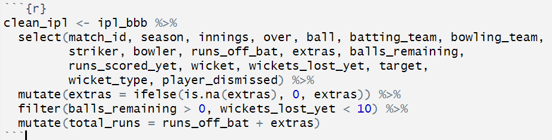

After cleaning:

- **Training rows:** 124,666
- **Test rows:** 8,092
- **Target variable:** `won` (binary 0/1 for team victory)

Training/Test Split

- Training set: Seasons 2008-2024
- Test set: Season 2025

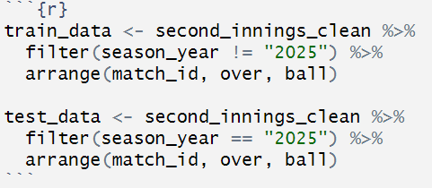

Choosing variables that are most valuable

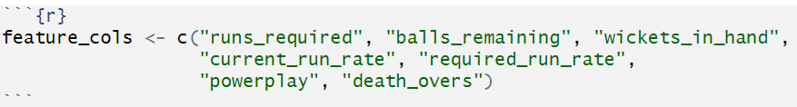

Focusing on the Second Innings data only

Restricting the analysis to the second innings provides several modeling advantages:

- The target score is fixed, allowing clear definition of runs required and win probability.
- The outcome variable (won) is known at every ball - unlike first innings, where the eventual chase context is unknown.
- It reflects real-time prediction opportunities during live matches.

In practice, this choice transforms the problem into a dynamic binary classification task, where each ball in the chase is a new observation with updated state variables.

## **3. Logistic Regression Model**

The logistic regression was used as a **baseline model**, trained to predict the probability of winning (`won`) from seven continuous and categorical features.

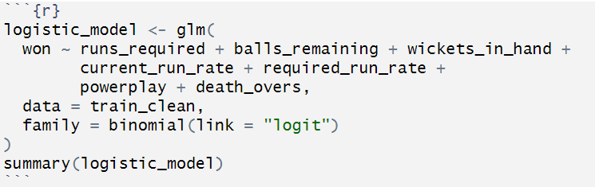

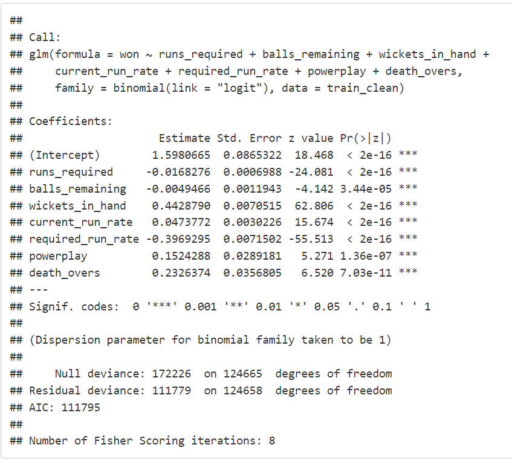

**Key insights:**

- **Required run rate** had a strong negative coefficient (high pressure reduces win chance).
- **Wickets in hand** and **current run rate** had positive effects, confirming the expected cricket intuition.
- **Model convergence warnings** occurred due to extreme match states (outcomes nearly deterministic).

**Performance summary:**

- Training mean predicted probability: **0.465**
- Test mean: **0.390**
- Indicates mild underconfidence (slight underprediction of win chance).

## **4. Random Forest Model**

To capture nonlinear interactions, a **Random Forest classifier** was trained using the same features.

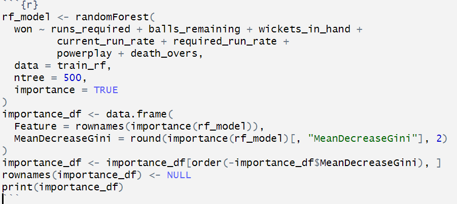

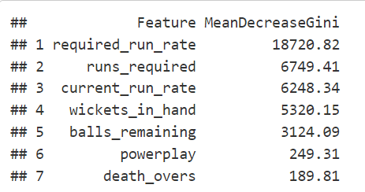

**Top Predictors (MeanDecreaseGini):**

1. `required_run_rate` – 18720.82
2. `runs_required` – 6749.41
3. `current_run_rate` – 6248.34
4. `wickets_in_hand` – 5320.15

**Out-of-Bag Error:** = 19.05%

**Calibration:**

- Actual test win rate = 0.475
- RF average predicted = 0.380
- **Miscalibration = 0.095**, indicating conservative predictions.

## **5. XGBoost Model**

The final model used **gradient boosting with monotonic constraints**, ensuring cricket-aware behavior (win probability increases with wickets, decreases with required rate).

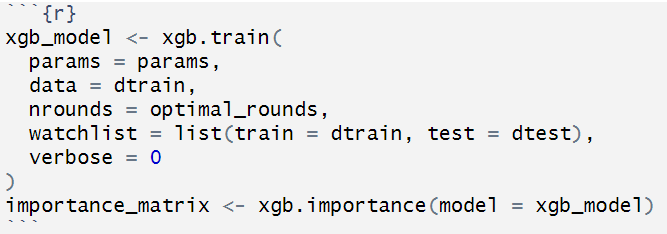

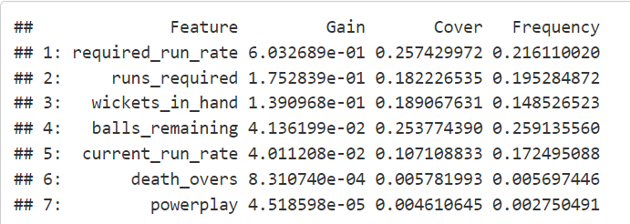

**Cross-validation log-loss:** 0.4383 **Best test set calibration:** = 0.0724 (smallest among all models). **Training time:** 7.6 s — fastest of the ensemble models.

*Handles 2025 data better than others* *Cricket-aware monotone constraints ensure logical predictions*

## **6. Comparative Evaluation**

| Metric | Logistic | Random Forest | XGBoost |
| --- | --- | --- | --- |
| Train Mean | 0.465 | 0.463 | **0.466** |
| Test Mean | 0.390 | 0.380 | **0.403** |
| Calibration | 0.085 | 0.095 | **0.072** |
| Top Predictor | Required RR | Required RR | Required RR |
| Correlation (Logit vs RF) | 0.905 | — | — |

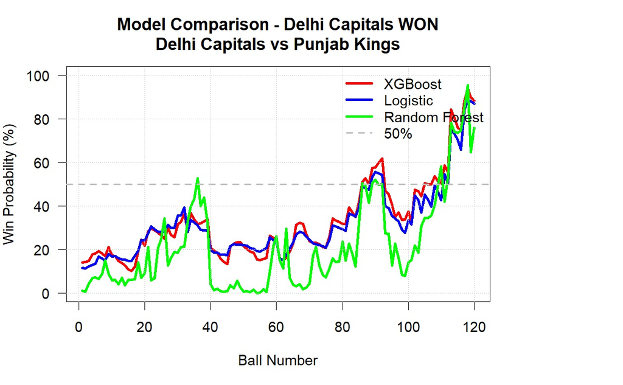

## **7. Model Validation & Visualization**

ROC curves were plotted for all models on 2025 test data:

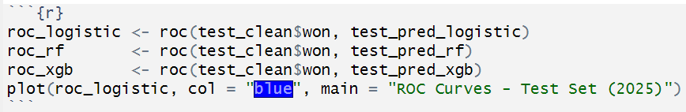

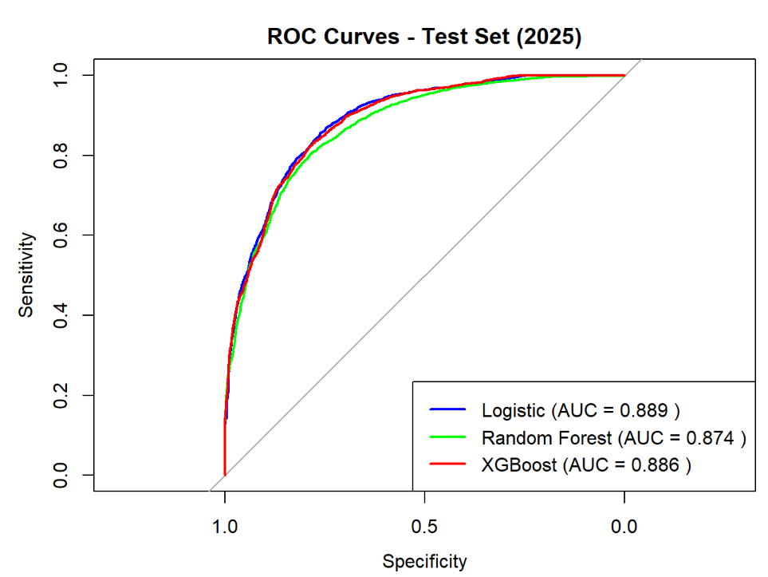

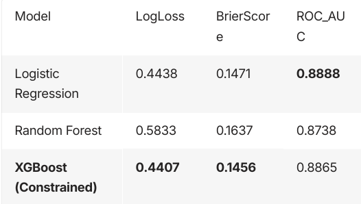

Overall, XGBoost generalizes best on unseen data, offering accurate, well-calibrated, and cricket-aware win probability estimates that track real match situations effectively.

## **8. Key Findings and Practical Use**

**Model Characteristics**

- **Training samples:** 124,666 balls (2008–2024)
- **Test samples:** 8,092 balls (2025)
- **Features:** 7 match-state variables

**Practical Applications**

- **Real-time win probability tracking** for live IPL broadcasts
- **In-game strategy optimization** (e.g., wicket conservation, over pacing)
- **Enhanced fan engagement** via dynamic win probability graphics

## **9. Validation on IPL 2025 Matches**

Using test data for 72 matches in IPL 2025:

| Example Match | Target | Final Score | Predicted Win |
| --- | --- | --- | --- |
| DC vs PK | 207 | 208 | 88.2% |

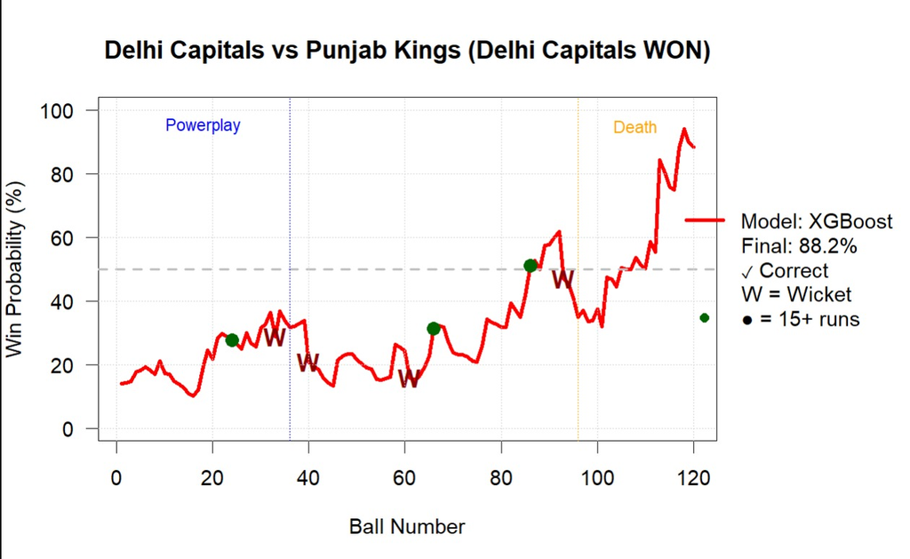

The model correctly identified 59 out of 72 outcomes (≈ 82% accuracy), with good discrimination across venues and toss results.